# 20200407_서점의_고객데이터에_대한_가상사례

# 주로 비싼 책을 샀는지를 파악하기 위해 평균금액을 계산

결과 : 소비자는 저렴한 책을 더 많이 구매한 것으로 보아, 앞으로 저렴한 책 위주로 판매하는 것이 더 효과적이다.

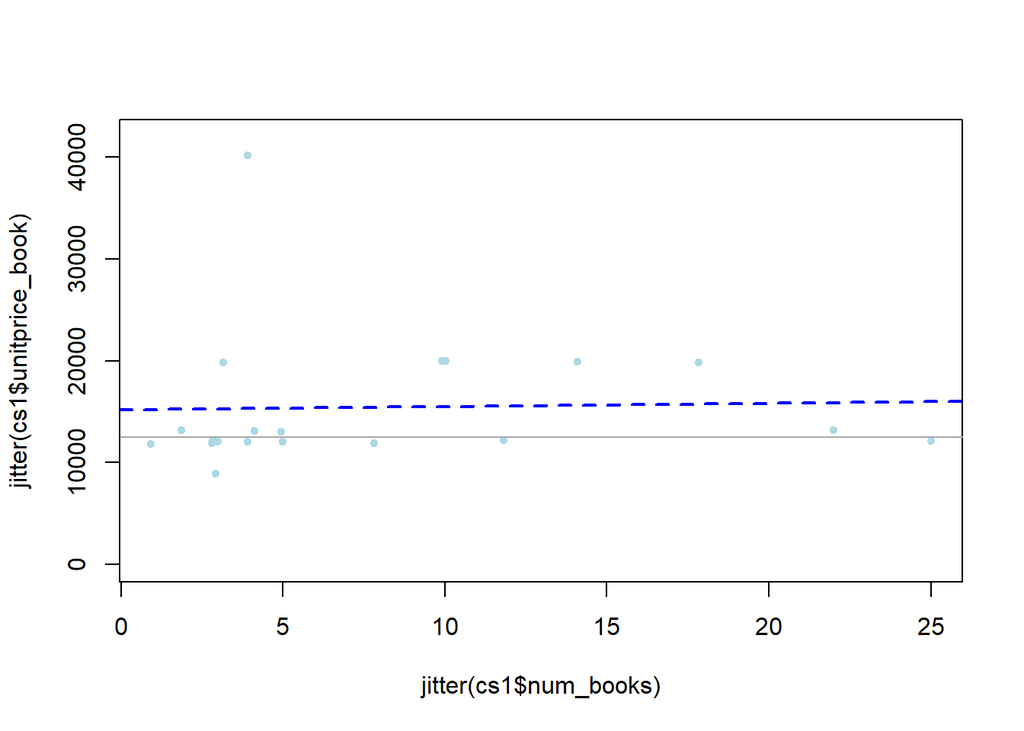

```r
cs1$unitprice_book <- cs1$amt_books / cs1$num_books

plot(jitter(cs1$num_books),
     jitter(cs1$unitprice_book),
     pch=19,
     col="lightblue",
     cex=0.7,
     ylim=c(0, max(cs1$unitprice_book)*1.05))

abline(lm(cs1$unitprice_book~cs1$num_books), col="blue", lwd=2, lty=2)

abline(h=median(cs1$unitprice_book), col="darkgrey")
```

# 성별을 구분해서 특성 차이 비교

결과 : 남자가 여자보다 책을 더 많이 구매했다.

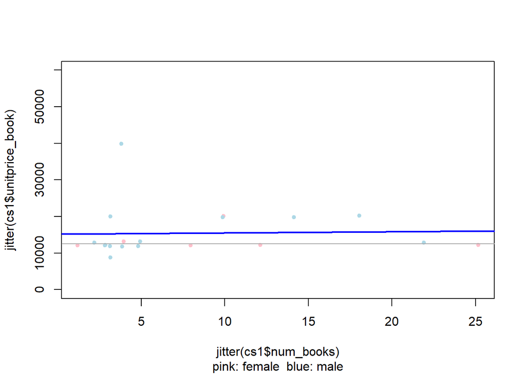

```r
plot(jitter(cs1$num_books),
     jitter(cs1$unitprice_book),
     pch=19,
     cex=0.7,
     col=ifelse(cs1$sex=="여", "pink", "lightblue"),
     ylim=c(0, max(cs1$unitprice_book)*1.5),
     sub="pink: female  blue: male")

abline(lm(cs1$unitprice_book~cs1$num_books), col="blue", lwd=2, lty2)
abline(h=median(cs1$unitprice_book), col="darkgrey")
```

# 서적과 서적이외 구매액 비교

결과 : 여자가 남자보다 서적이외 상품 구매금액이 더 크다.

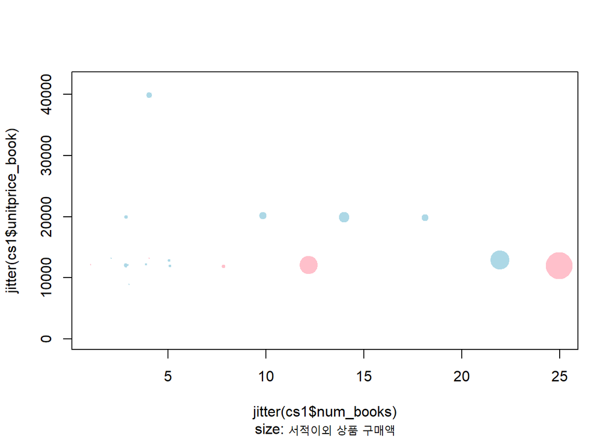

```r
# 동그라미 크기 비율 조정
plot(jitter(cs1$num_books),
     jitter(cs1$unitprice_book),
     pch=19,
     cex=4*cs1$amt_non_book/max(cs1$amt_non_book),
     col=ifelse(cs1$sex=="여", "pink", "lightblue"),
     ylim=c(0, max(cs1$unitprice_book)*1.05),
     sub="size: 서적이외 상품 구매액")
```

# 서적 구매는 많으나 기타 상품 구매가 약한 집단을 선정해

# 집중적 cross-selling 노력 기울이는 것이 필요해보인다.

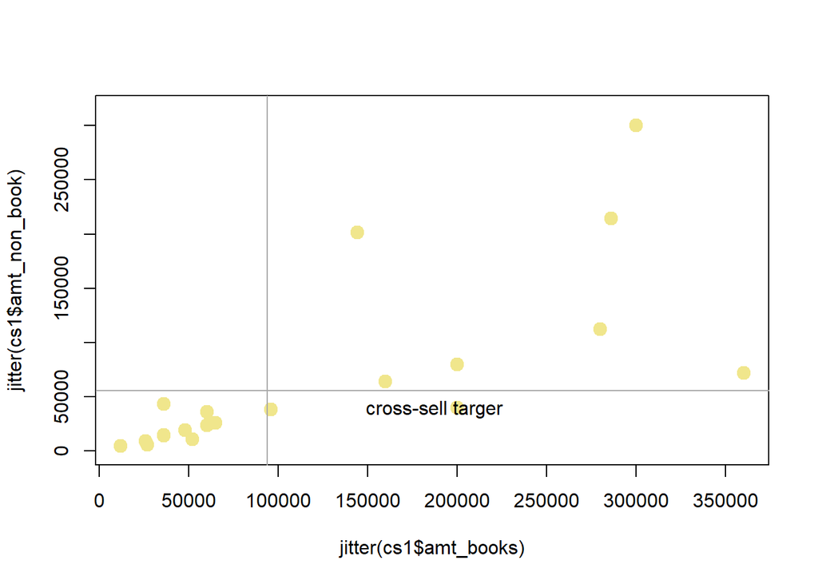

```r
plot(jitter(cs1$amt_books),
     jitter(cs1$amt_non_book),
     pch=19,
     col="khaki",
     cex=1.5,
     ylim=c(0, max(cs1$amt_non_book)*1.05))

abline(h=median(cs1$amt_non_book)*1.5, col="darkgrey")
abline(v=median(cs1$amt_books)*1.5, col="darkgrey")

text(median(cs1$amt_books)*1.5 *2,
     median(cs1$amt_non_book)*1.5 *0.7, "cross-sell targer")
```

# 대상 집단 조건 - 시각적으로 설정했던 기준선 영역에 해당하는 고객 리스트 추출

```r
target <- cs1[cs1$amt_books > median(cs1$amt_books)*1.5 &
                cs1$amt_non_book < median(cs1$amt_non_book)*1.5 ,]

nrow(target)
```

[1] 2

```r
paste("size of target = ",
      as.character(100* nrow(target)/ nrow(cs1)),
      " % of customer base")
```

[1] “size of target = 10 % of customer base”

```r
# => 타겟층 10%
```

# 선정된 집단의 프로파일 시각적으로 확인

# 서적 구매수량과 성별 분포 확인 (여성은 pink)

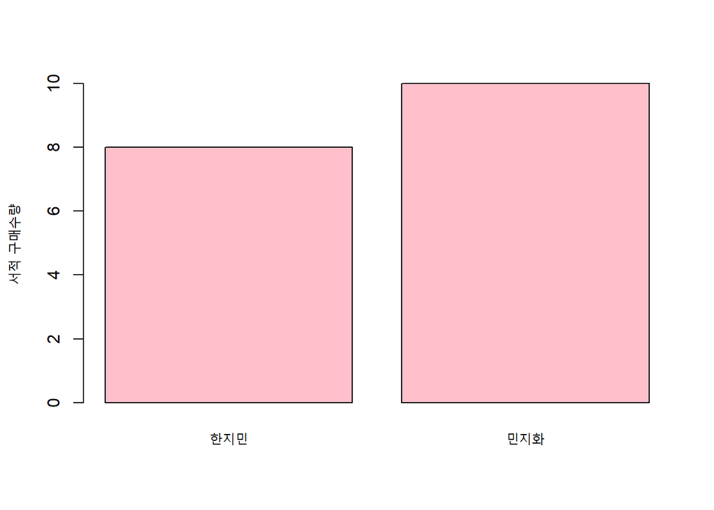

```r
barplot(target$num_books,
        names.arg=target$cust_name,
        col=ifelse(target$sex=="여", "pink", "lightblue"),
        ylab="서적 구매수량")
```

```r
# 한지민, 민지화
```

# 전체고객의 평균/중위수 서적구매수량과 비교

결과 : 중위수와 평균에 비해서 서적구매수량이 많은 고객 성별은 여성 고객.

집중 타겟 고객 : 한지민, 민지화

기타 상품 중 여성 선호 상품을 찾아 제안하는 방식으로 cross-sell 캠페인 진행 필요해보임

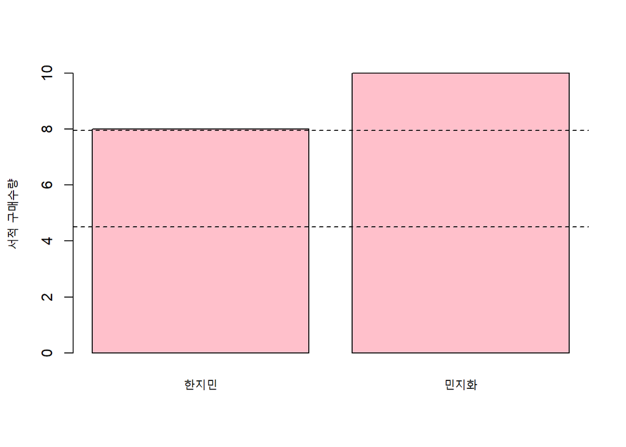

```r
barplot(target$num_books,
        names.arg=target$cust_name,
        col=ifelse(target$sex=="여", "pink", "lightblue"),
        ylab="서적 구매수량")

abline(h=mean(cs1$num_books), lty=2)
abline(h=median(cs1$num_books), lty=2)
```

#군집분석을 활용한 고객세분화

```r
cs2 <- cs1[, names(cs1) %in% c("days_purchase", "recency",
                               "num_books", "amt_books",
                               "unitprice_book", "amt_non_book",
                               "num_genre", "membership_period")]


kmm1 <- kmeans(cs2, 3)

table(kmm1$cluster)
```

1 2 3 4 12 4

# 고객집단을 표시할 색상을 임의로 지정

# 번호순의 색상 이름 벡터 생성

# 각 고객의 소속 집단이 어디인가에 따라 색상 표시

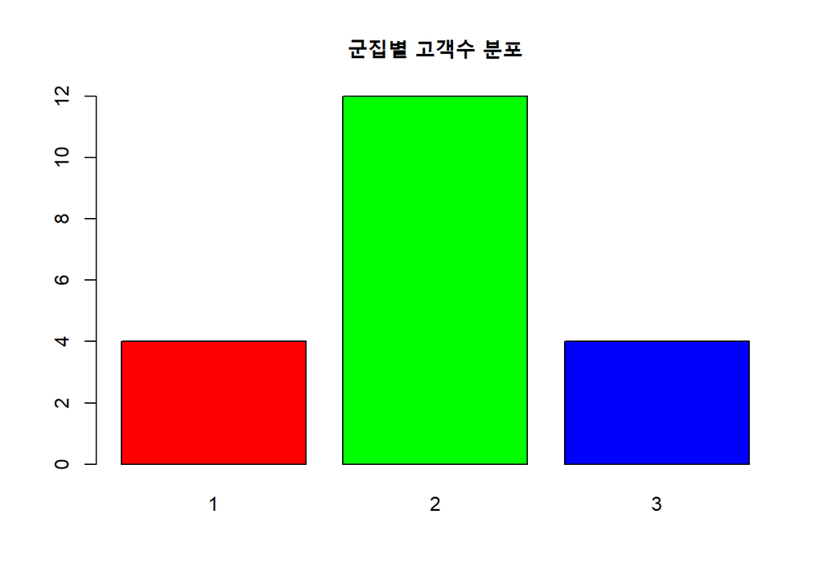

```r
cols <- c("red", "green", "blue")
barplot(table(kmm1$cluster),
        names.arg=names(table(kmm1$cluster)),
        col=cols,
        main="군집별 고객수 분포")
```

# 구매빈도와 서적구매 장르 다양성 분포

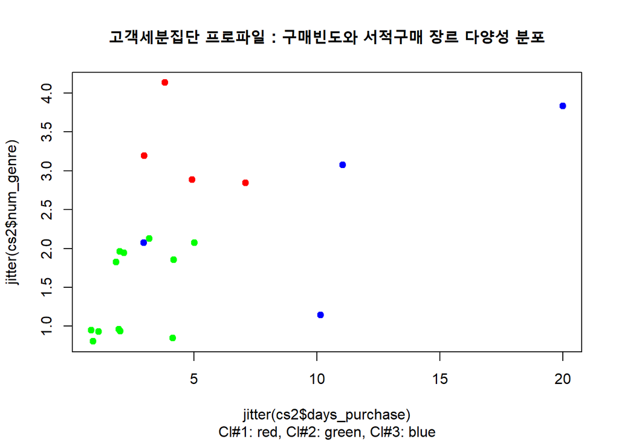

```r
plot(jitter(cs2$days_purchase),
     jitter(cs2$num_genre),
     col=cols[kmm1$cluster],
     pch=19,
     main="고객세분집단 프로파일 : 구매빈도와 서적구매 장르 다양성 분포",
     sub="Cl#1: red, Cl#2: green, Cl#3: blue")
```

#구매 빈도와 서적구매량대비 장르 다양성 분포

결과 : 구매빈도가 낮을수록 서적구매량대비 구매장르수 비율이 높다.

따라서 구매빈도가 낮은 고객층에겐 다양한 장르의 서적을 추천하는 것이 매출을 올리는데 효과적일 것이다.

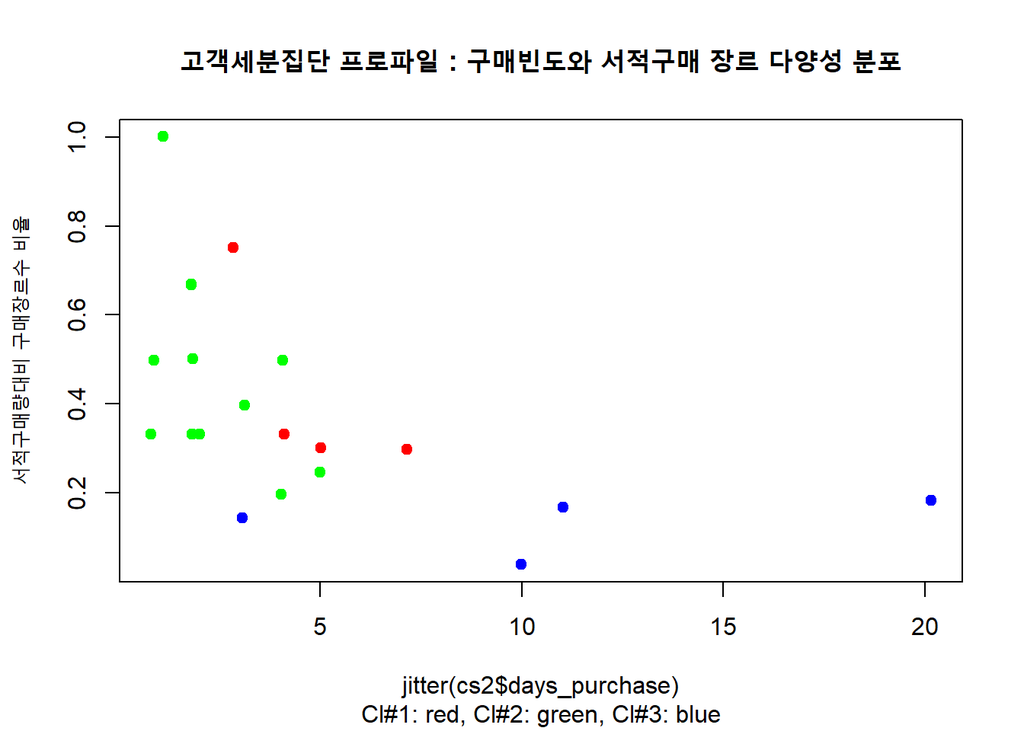

```r
plot(jitter(cs2$days_purchase),
     jitter(cs2$num_genre/cs2$num_books),
     col=cols[kmm1$cluster],
     pch=19,
     main="고객세분집단 프로파일 : 구매빈도와 서적구매 장르 다양성 분포",
     sub="Cl#1: red, Cl#2: green, Cl#3: blue",
     ylab="서적구매량대비 구매장르수 비율")
```